# Visual EDA

# Reading

- Reading: Weissgerber et al. (2015)
- Further reading: Healy (2018), ch. 1; Matejka and Fitzmaurice (n.d.)

# The Role of Visuals in EDA

- Tukey (1977) emphasized visual methods for EDA
- Including not just graphs but also structured tables, such as [stem-and-leaf displays](https://en.wikipedia.org/wiki/Stem-and-leaf_display)

[figure not shown]

A stem-and-leaf display, promoted by Tukey for use in EDA

# In terms of our models of EDA

### Epicycle of analysis

- Check expectations about the distribution of variables
  - Outliers
  - Degeneracies (eg, perfect correlation)
  - Skew or bimodal distributions
  - Non-linear relationships
- Develop expectations about relationships between variables

### Phenomena development

- Quickly identify potential patterns
- Contrast potential patterns with noise/uncertainty/imprecision

# Plot Your Data

- Summary statistics almost always focus only on central tendency (mean, median) and dispersion (standard deviation, IQR)
  - This is all you would need if the world were made of normal distributions
    - (Or at least unimodal symmetric ones)
  - The world is not made of normal distributions (Lyon 2014)
    - (Or even unimodal symmetric ones)
- We’ll illustrate this using The Datasaurus Dozen (Matejka and Fitzmaurice n.d.)

```r
library(tidyverse)
library(datasauRus)
library(ggforce)

## We'll need this, but don't want to load it
## install.packages('Hmisc')

theme_set(theme_minimal())

ds_df = datasaurus_dozen
```

- The dataset combines 13 different datasets with $n=142$ for each

```r
ds_df
```

| dataset | x | y |
| --- | --- | --- |
| dino | 55.38460 | 97.17950000 |
| dino | 51.53850 | 96.02560000 |
| dino | 46.15380 | 94.48720000 |
| dino | 42.82050 | 91.41030000 |
| dino | 40.76920 | 88.33330000 |
| dino | 38.71790 | 84.87180000 |
| dino | 35.64100 | 79.87180000 |
| dino | 33.07690 | 77.56410000 |
| dino | 28.97440 | 74.48720000 |
| dino | 26.15380 | 71.41030000 |

[output cut: 1836 more lines]

```r
count(ds_df, dataset)
```

| dataset | n |
| --- | --- |
| away | 142 |
| bullseye | 142 |
| circle | 142 |
| dino | 142 |
| dots | 142 |
| h_lines | 142 |
| high_lines | 142 |
| slant_down | 142 |
| slant_up | 142 |
| star | 142 |

[output cut: 3 more lines]

- The datasets have the same means, standard deviations, and (Pearson) correlation coefficient
  - p-value of the correlation coefficient is not statistically significant

```r
## This is a more complex summarize() call than we've seen before
## 1. Number of rows
## 2. "Summarize across the columns x and y, using the functions mean and sd"; automatically generates names
## 3. Correlation between x and y
## 4. p-value from a t-test of the null that the correlation = 0
ds_df %>%
    group_by(dataset) %>%
    summarize(n = n(),
              across(.cols = c(x, y),
                     .fns = lst(mean, sd)),
              cor_xy = cor(x, y),
              p_value = cor.test(x, y)$p.value) %>%
    ungroup()
```

| dataset | n | x_mean | x_sd | y_mean | y_sd | cor_xy | p_value |
| --- | --- | --- | --- | --- | --- | --- | --- |
| away | 142 | 54.26610 | 16.76982 | 47.83472 | 26.93974 | -0.06412835 | 0.4483288 |
| bullseye | 142 | 54.26873 | 16.76924 | 47.83082 | 26.93573 | -0.06858639 | 0.4173467 |
| circle | 142 | 54.26732 | 16.76001 | 47.83772 | 26.93004 | -0.06834336 | 0.4190029 |
| dino | 142 | 54.26327 | 16.76514 | 47.83225 | 26.93540 | -0.06447185 | 0.4458966 |
| dots | 142 | 54.26030 | 16.76774 | 47.83983 | 26.93019 | -0.06034144 | 0.4756316 |
| h_lines | 142 | 54.26144 | 16.76590 | 47.83025 | 26.93988 | -0.06171484 | 0.4656268 |
| high_lines | 142 | 54.26881 | 16.76670 | 47.83545 | 26.94000 | -0.06850422 | 0.4179063 |
| slant_down | 142 | 54.26785 | 16.76676 | 47.83590 | 26.93610 | -0.06897974 | 0.4146744 |
| slant_up | 142 | 54.26588 | 16.76885 | 47.83150 | 26.93861 | -0.06860921 | 0.4171915 |
| star | 142 | 54.26734 | 16.76896 | 47.83955 | 26.93027 | -0.06296110 | 0.4566492 |

[output cut: 3 more lines]

- But, when plotted, they’re obviously very different

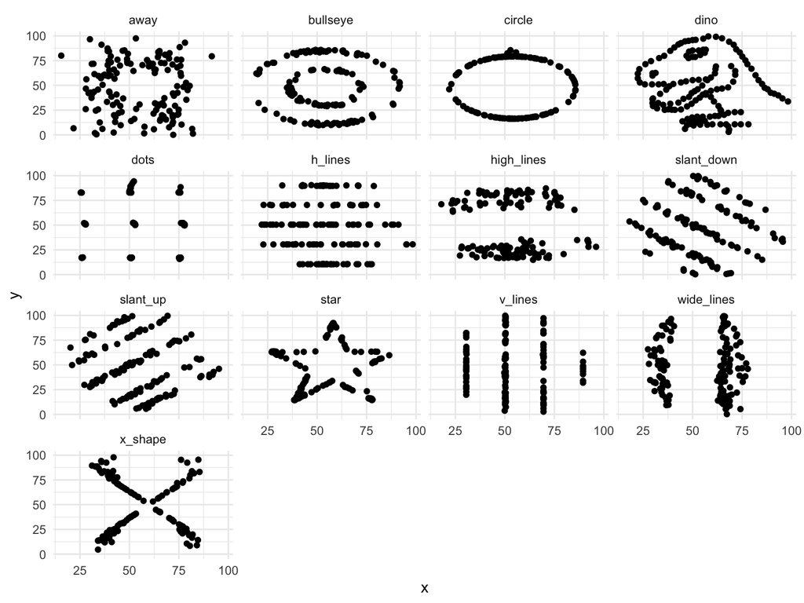

```r
ggplot(ds_df, aes(x, y)) +
    geom_point() +
    facet_wrap(vars(dataset))
```